# Lab’s 2-1 Reg-simple-mtcars

M.NEKUI TIEFANG BIEDIANT

2023-03-09

```r
data("mtcars")
attach(mtcars)
head(mtcars)
```

```
##                    mpg cyl disp  hp drat    wt  qsec vs am gear carb
## Mazda RX4         21.0   6  160 110 3.90 2.620 16.46  0  1    4    4
## Mazda RX4 Wag     21.0   6  160 110 3.90 2.875 17.02  0  1    4    4
## Datsun 710        22.8   4  108  93 3.85 2.320 18.61  1  1    4    1
## Hornet 4 Drive    21.4   6  258 110 3.08 3.215 19.44  1  0    3    1
## Hornet Sportabout 18.7   8  360 175 3.15 3.440 17.02  0  0    3    2
## Valiant           18.1   6  225 105 2.76 3.460 20.22  1  0    3    1
```

Les données ont été extraites du magazine américain Motor Trend et comprennent la consommation de carburant et 10 aspects de la conception et des performances automobiles pour 32 automobiles

DESCRIPTION [, 1] mpg Miles/(US) gallon *la distance en km, qu’une voiture peut parcourir par gallon de carburant.* [, 2] cyl Number of cylinders [, 3] disp Displacement (cu.in.)*est le volume balayé par le déplacement d’une pièce mobile dans une chambre hermétiquement close pour un mouvement unitaire.* [, 4] hp Gross horsepower *puissance brute* [, 5] drat Rear axle ratio *Rapport de transmision pont arrière* [, 6] wt Weight (1000 lbs) *poid* [, 7] qsec 1/4 mile time *temps de parcours de 400m* [, 8] vs Engine (0 = V-shaped, 1 = straight) [, 9] am Transmission (0 = automatic, 1 = manual) [,10] gear Number of forward gears *Nombre de vitesses avant* [,11] carb *Nombre de carburateurs*

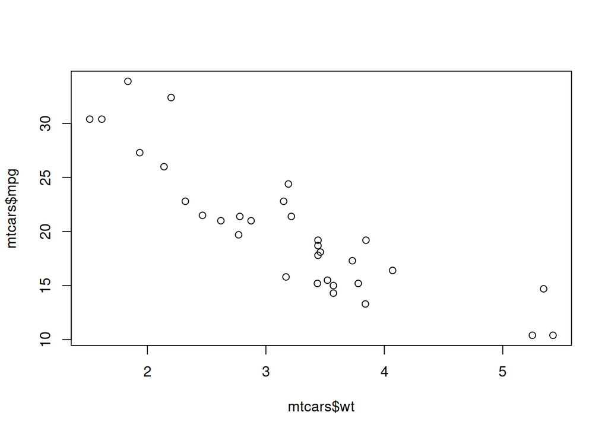

```r
plot(mtcars$mpg~mtcars$wt)
```

```r
model=lm(mpg~wt, data = mtcars)
summary(model)
```

```
##
## Call:
## lm(formula = mpg ~ wt, data = mtcars)
##
## Residuals:
##     Min      1Q  Median      3Q     Max
## -4.5432 -2.3647 -0.1252  1.4096  6.8727
##
## Coefficients:
##             Estimate Std. Error t value Pr(>|t|)
## (Intercept)  37.2851     1.8776  19.858  < 2e-16 ***
## wt           -5.3445     0.5591  -9.559 1.29e-10 ***
## ---
## Signif. codes:  0 '***' 0.001 '**' 0.01 '*' 0.05 '.' 0.1 ' ' 1
##
## Residual standard error: 3.046 on 30 degrees of freedom
## Multiple R-squared:  0.7528, Adjusted R-squared:  0.7446
## F-statistic: 91.38 on 1 and 30 DF,  p-value: 1.294e-10
```

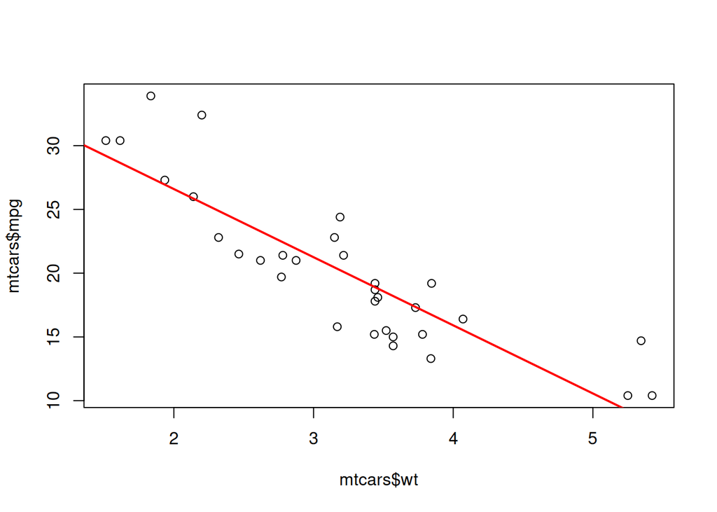

```r
plot(mtcars$mpg~mtcars$wt)
abline(model,col="red",lwd=2)
```

passons aux diagnostique du model

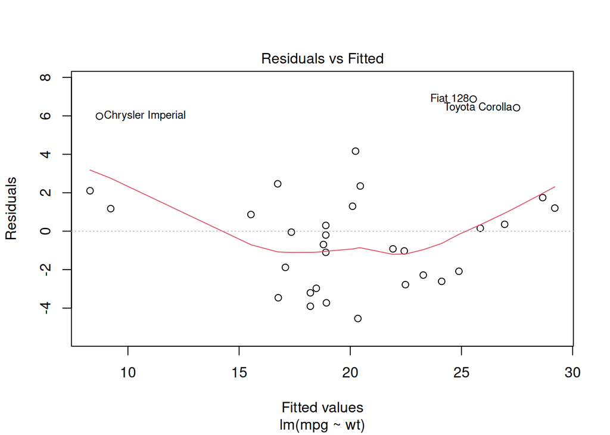

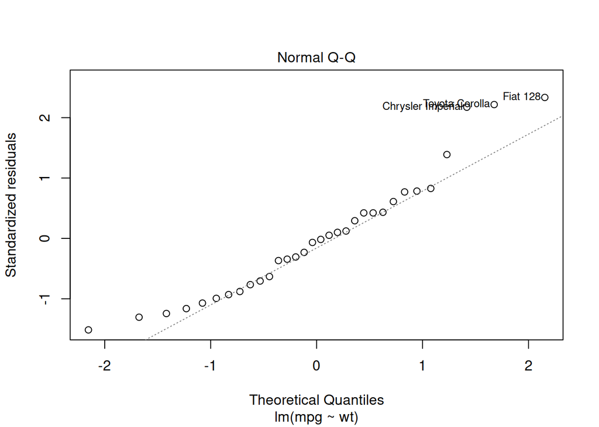

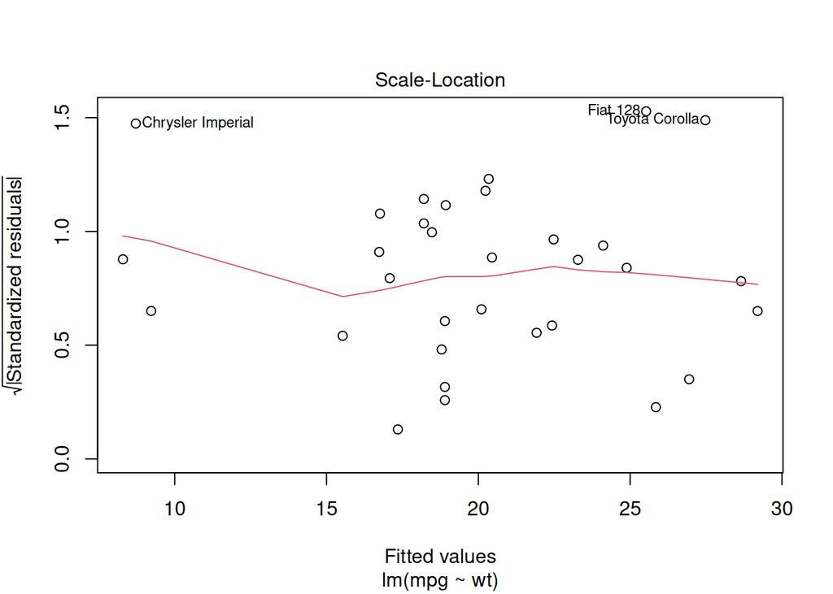

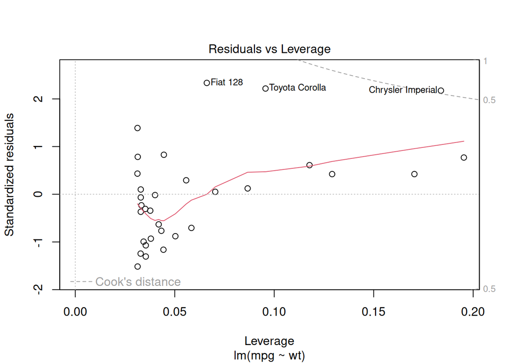

```r
plot(model)
```

ici l’ideal est que la ligne rouge soit le plus horizontale possible!! ce qui n’est pas encore le cas visiblement !!! mais sa n’empêche que le modèle soit expliqué a 74% le mpg

```
                               passons now a un model polynomial
```

```r
modelP2=lm(mpg~ +wt+I(wt^2), data = mtcars)
summary(modelP2)
```

```
##
## Call:
## lm(formula = mpg ~ +wt + I(wt^2), data = mtcars)
##
## Residuals:
##    Min     1Q Median     3Q    Max
## -3.483 -1.998 -0.773  1.462  6.238
##
## Coefficients:
##             Estimate Std. Error t value Pr(>|t|)
## (Intercept)  49.9308     4.2113  11.856 1.21e-12 ***
## wt          -13.3803     2.5140  -5.322 1.04e-05 ***
## I(wt^2)       1.1711     0.3594   3.258  0.00286 **
## ---
## Signif. codes:  0 '***' 0.001 '**' 0.01 '*' 0.05 '.' 0.1 ' ' 1
##
## Residual standard error: 2.651 on 29 degrees of freedom
## Multiple R-squared:  0.8191, Adjusted R-squared:  0.8066
## F-statistic: 65.64 on 2 and 29 DF,  p-value: 1.715e-11
```

cool une amelioration ! Le medel explique a 80.66% le mpg daignostiquons le

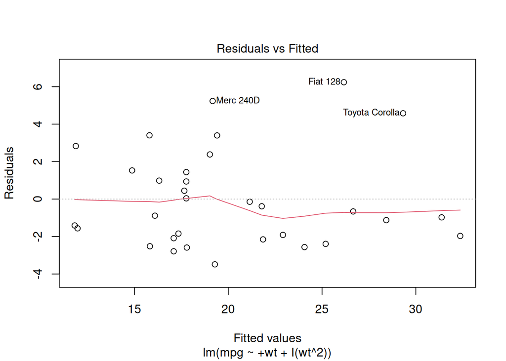

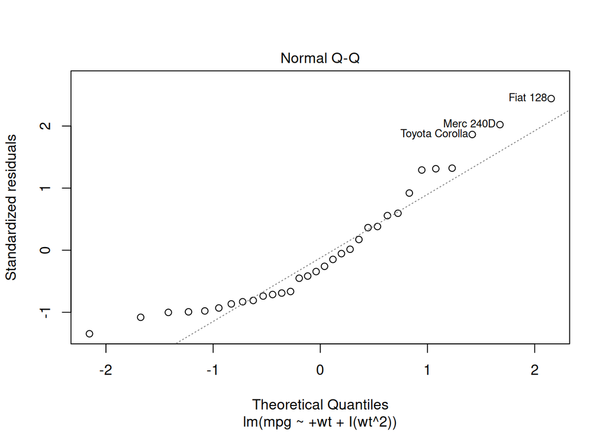

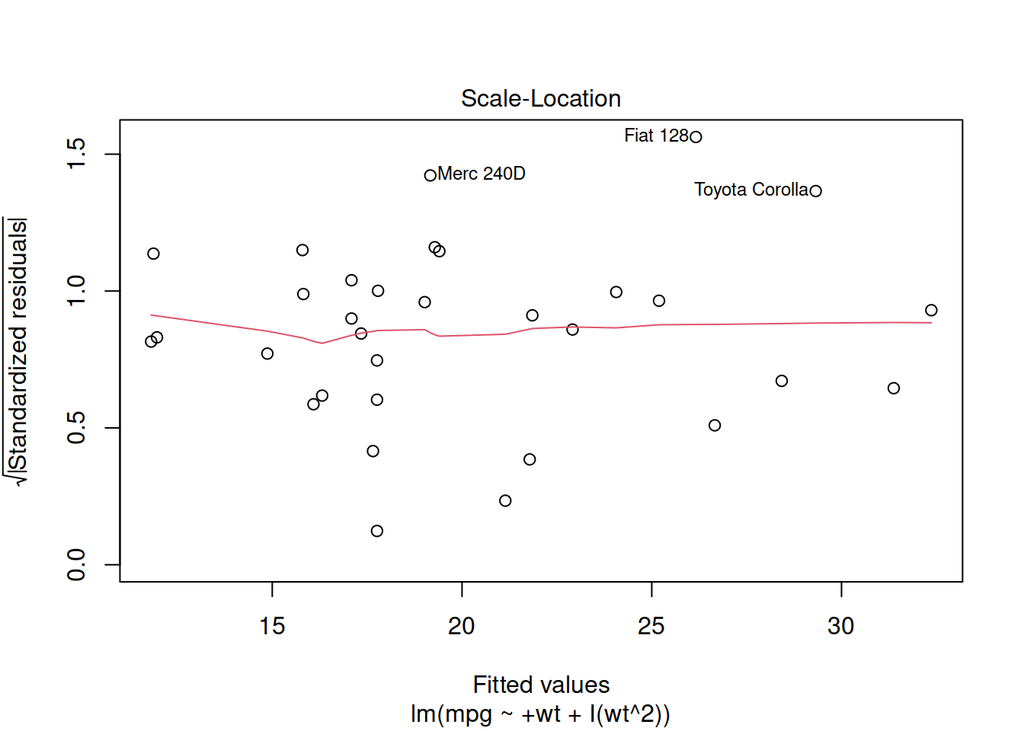

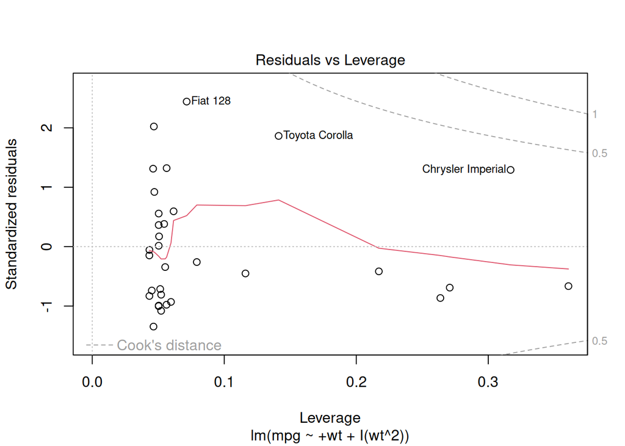

```r
plot(modelP2)
```

la courbe tend vers une ligne horizontale nettement mieux que la précédante

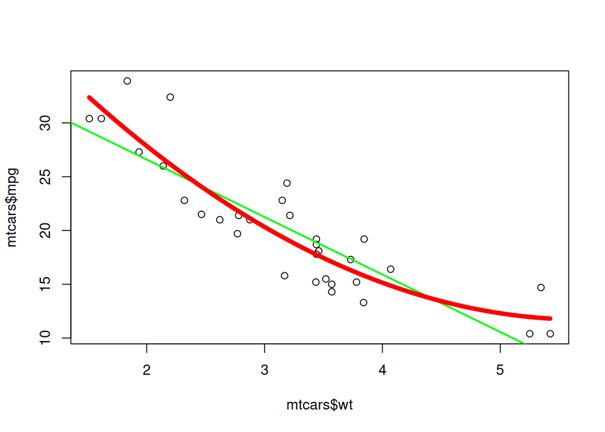

```r
plot(mtcars$mpg~mtcars$wt)
abline(model,col="green",lwd=2)
wt.seq=seq(min(wt),max(wt), by=0.01)
mpg.predict=predict.lm(modelP2,data.frame(wt=wt.seq))
lines(wt.seq ,mpg.predict,col="red",lwd=5)
```

nous continuons avec une équation d’ordre 3

```r
modelP3=lm(mpg~wt+I(wt^2)+I(wt^3), data = mtcars)
summary(modelP3)
```

```
##
## Call:
## lm(formula = mpg ~ wt + I(wt^2) + I(wt^3), data = mtcars)
##
## Residuals:
##    Min     1Q Median     3Q    Max
## -3.506 -1.999 -0.768  1.490  6.188
##
## Coefficients:
##              Estimate Std. Error t value Pr(>|t|)
## (Intercept)  48.40370   15.58379   3.106  0.00431 **
## wt          -11.82598   15.46346  -0.765  0.45081
## I(wt^2)       0.68938    4.74034   0.145  0.88541
## I(wt^3)       0.04594    0.45070   0.102  0.91954
## ---
## Signif. codes:  0 '***' 0.001 '**' 0.01 '*' 0.05 '.' 0.1 ' ' 1
##
## Residual standard error: 2.697 on 28 degrees of freedom
## Multiple R-squared:  0.8191, Adjusted R-squared:  0.7997
## F-statistic: 42.27 on 3 and 28 DF,  p-value: 1.585e-10
```

oups le model d’ordre 3 explique moin bien que le precedant d’ordre 2

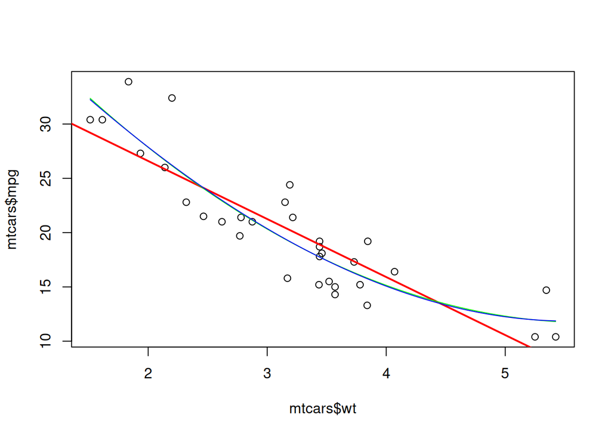

```r
plot(mtcars$mpg~mtcars$wt)
abline(model,col="red",lwd=2)
wt.seq=seq(min(wt),max(wt), by=0.01)
mpg.predict=predict.lm(modelP2,data.frame(wt=wt.seq))
lines(wt.seq ,mpg.predict,col="green")


mpg.predict1=predict.lm(modelP3,data.frame(wt=wt.seq))
lines(wt.seq ,mpg.predict1,col="blue")
```

quasiment identique nespas !!! mais le model d’ordre 2 est plus pertinant

evoluons

```r
modelP4=lm(mpg~poly(wt,4),data = mtcars)
summary(modelP4)
```

```
##
## Call:
## lm(formula = mpg ~ poly(wt, 4), data = mtcars)
##
## Residuals:
##     Min      1Q  Median      3Q     Max
## -3.2158 -2.0436 -0.7734  1.2710  5.7726
##
## Coefficients:
##              Estimate Std. Error t value Pr(>|t|)
## (Intercept)   20.0906     0.4817  41.709  < 2e-16 ***
## poly(wt, 4)1 -29.1157     2.7248 -10.685 3.36e-11 ***
## poly(wt, 4)2   8.6358     2.7248   3.169  0.00378 **
## poly(wt, 4)3   0.2749     2.7248   0.101  0.92039
## poly(wt, 4)4  -1.7891     2.7248  -0.657  0.51701
## ---
## Signif. codes:  0 '***' 0.001 '**' 0.01 '*' 0.05 '.' 0.1 ' ' 1
##
## Residual standard error: 2.725 on 27 degrees of freedom
## Multiple R-squared:  0.822,  Adjusted R-squared:  0.7956
## F-statistic: 31.17 on 4 and 27 DF,  p-value: 9.211e-10
```

toujours pas mieux

```
  utilisation d'anova pour la comparaison des models
```

```r
anova(model,modelP2,modelP3,modelP4)
```

```
## Analysis of Variance Table
##
## Model 1: mpg ~ wt
## Model 2: mpg ~ +wt + I(wt^2)
## Model 3: mpg ~ wt + I(wt^2) + I(wt^3)
## Model 4: mpg ~ poly(wt, 4)
##   Res.Df    RSS Df Sum of Sq       F   Pr(>F)
## 1     30 278.32
## 2     29 203.75  1    74.576 10.0443 0.003779 **
## 3     28 203.67  1     0.076  0.0102 0.920390
## 4     27 200.47  1     3.201  0.4311 0.517008
## ---
## Signif. codes:  0 '***' 0.001 '**' 0.01 '*' 0.05 '.' 0.1 ' ' 1
```

même d’apres l’anova le model le plus significatif est le deuxième

```
sur ceux je vous remercie..............................................
```